# Blog 2

Thomas Hill

March 11, 2021

A bimodal distribution is a special case of a multimodal distribution that features two values of a given value or value range. When visualized as a histogram, these can appear as simply as two distinct bell curves, or more commonly as a dataset with a relative minimum somewhere in the middle of the histogram. Bimodal distributions are notable because they may indicate that another variable is interacting. Adult height is the classic example of a bimodal distribution, because sex interacts with otherwise predictable parameters. Other examples include age of diagnosis of breast and blood cancers, and diurnal cycles (road congestion, water and electricity usage).

For example, in HW1 there were three bimodal distributions to consider: TEAM_BATTING_HR, TEAM_BATTING_SO, and TEAM_PITCHING_HR. Even after changing bin widths, the bimodal distribution persisted. By omitting or transforming these features to approximate a normal distribution, this would lose potentially crucial information about baseball team performance. Here are the ideas I considered to model bimodal features.

```r
library(dplyr)
```

```r
library(ggplot2)
library(mixtools)
library(tidyr)
baseball_df <- read.csv('https://raw.githubusercontent.com/hillt5/DATA_621/master/HW1/moneyball-training-data.csv')
```

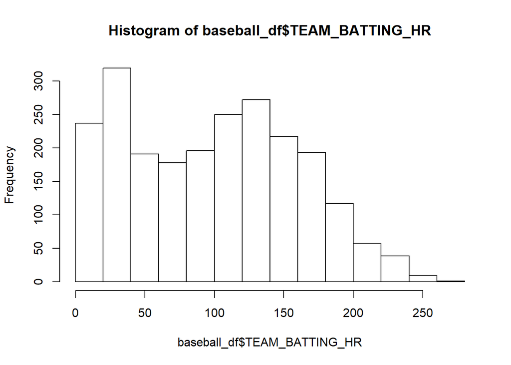

```r
hist(baseball_df$TEAM_BATTING_HR)
```

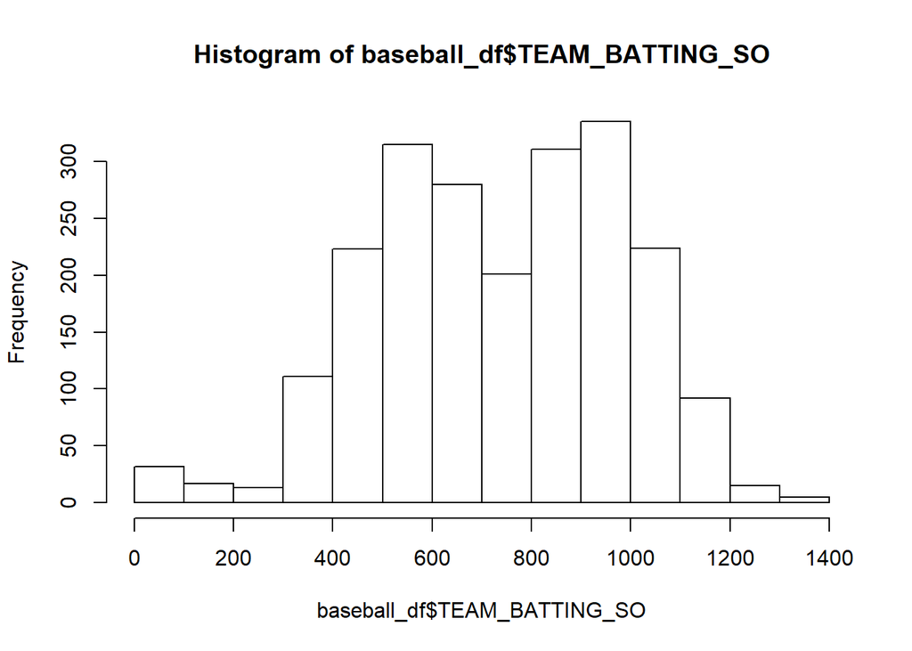

```r
hist(baseball_df$TEAM_BATTING_SO)
```

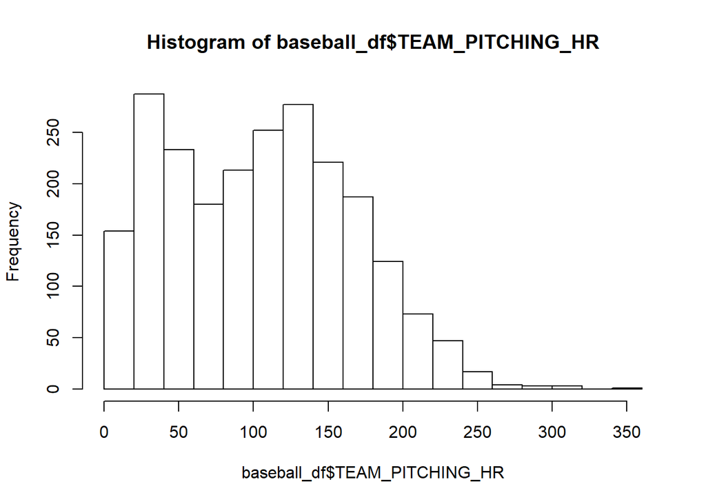

```r
hist(baseball_df$TEAM_PITCHING_HR)
```

My first idea was to demonstrate graphically that values could be separated by another model feature. I had an existing concern that missing values were not random and potentially based on changes to MLB strategy and recordkeeping. To test this, I plotted a histogram that colored the values by a dummy variable defined as missing versus not missing values.

```r
baseball_no_cs <- baseball_df %>%
  filter(is.na(TEAM_BASERUN_CS)) %>% #missing values for hbp
  dplyr::select(-TEAM_BASERUN_CS)  ## select all rows except hbp



baseball_cs <- baseball_df %>%
  filter(!is.na(TEAM_BASERUN_CS)) #not missing values for hbp
```

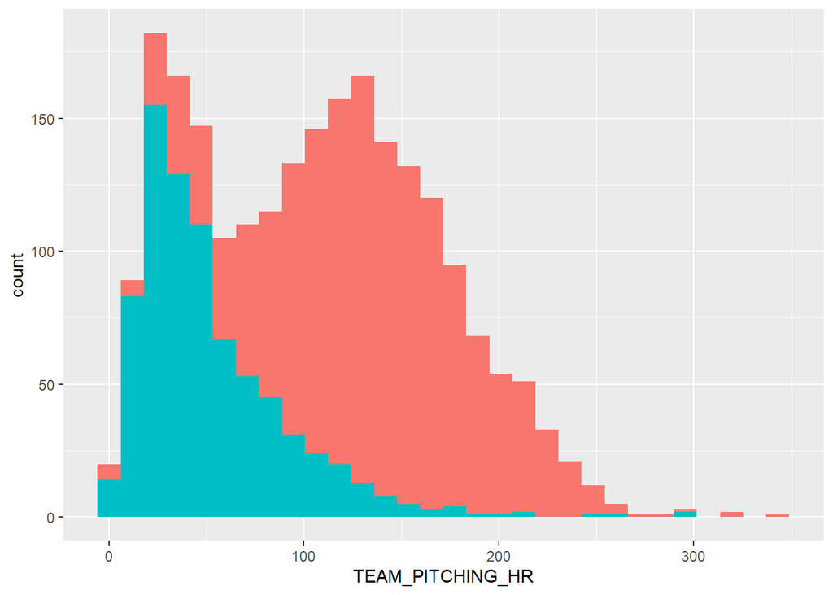

```r
baseball_cs_dummy <- baseball_df %>%
  mutate(TEAM_CS_YES_NO = case_when(!is.na(TEAM_BASERUN_CS) ~ 'Has CS record', is.na(TEAM_BASERUN_CS) ~ 'Has no CS record'))

ggplot(baseball_cs_dummy, aes(x = TEAM_PITCHING_HR, fill = TEAM_CS_YES_NO)) +
  geom_histogram() +
  theme(legend.position = 'none')
```

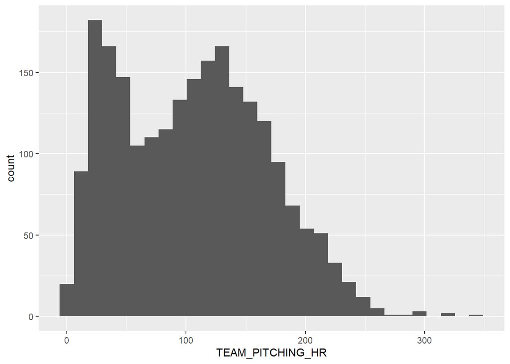

```r
ggplot(baseball_cs_dummy, aes(x = TEAM_PITCHING_HR)) +
  geom_histogram()
```

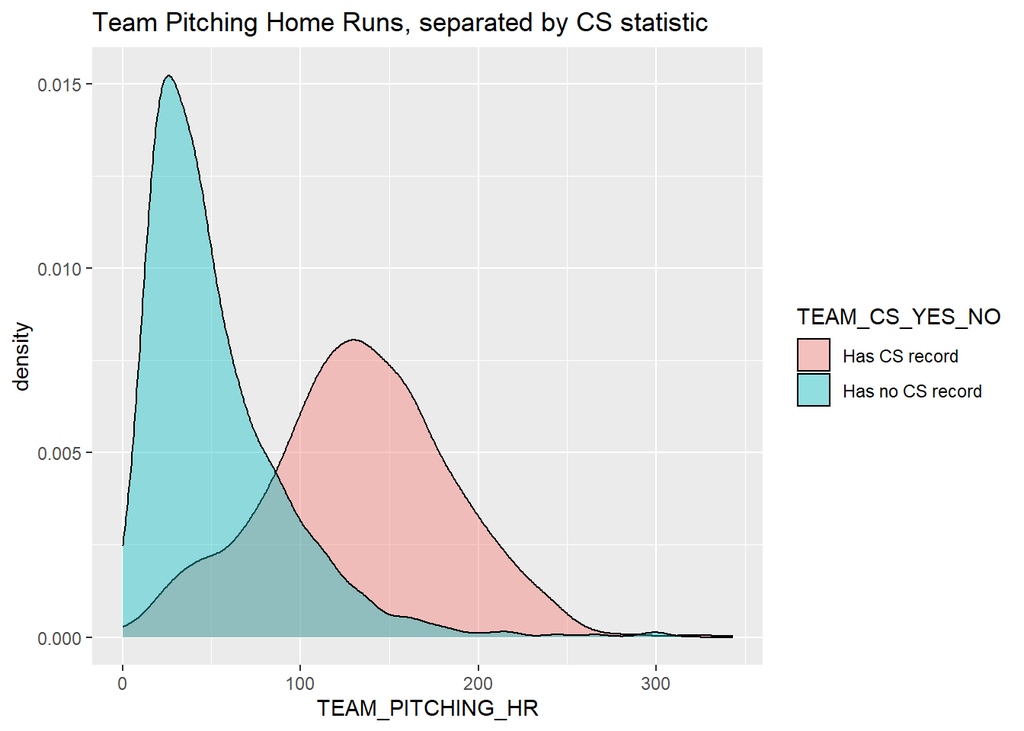

```r
ggplot(baseball_cs_dummy, aes(TEAM_PITCHING_HR, fill = TEAM_CS_YES_NO)) +
  ggtitle('Team Pitching Home Runs, separated by CS statistic') +
  geom_density(alpha = 0.4)
```

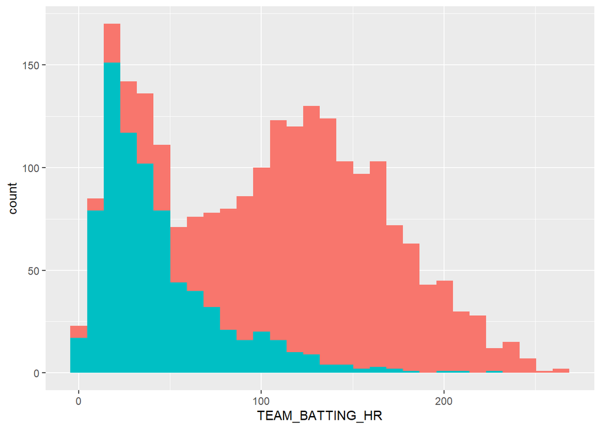

```r
ggplot(baseball_cs_dummy, aes(x = TEAM_BATTING_HR, fill = TEAM_CS_YES_NO)) +
  geom_histogram() +
  theme(legend.position = 'none')
```

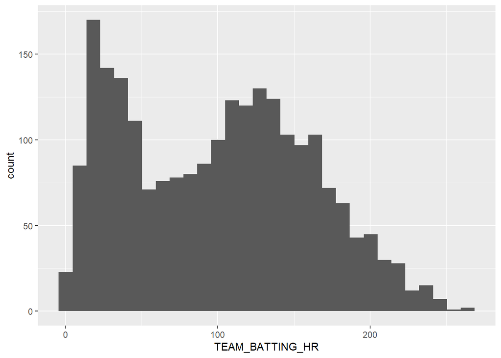

```r
ggplot(baseball_df, aes(x = TEAM_BATTING_HR)) +
  geom_histogram()
```

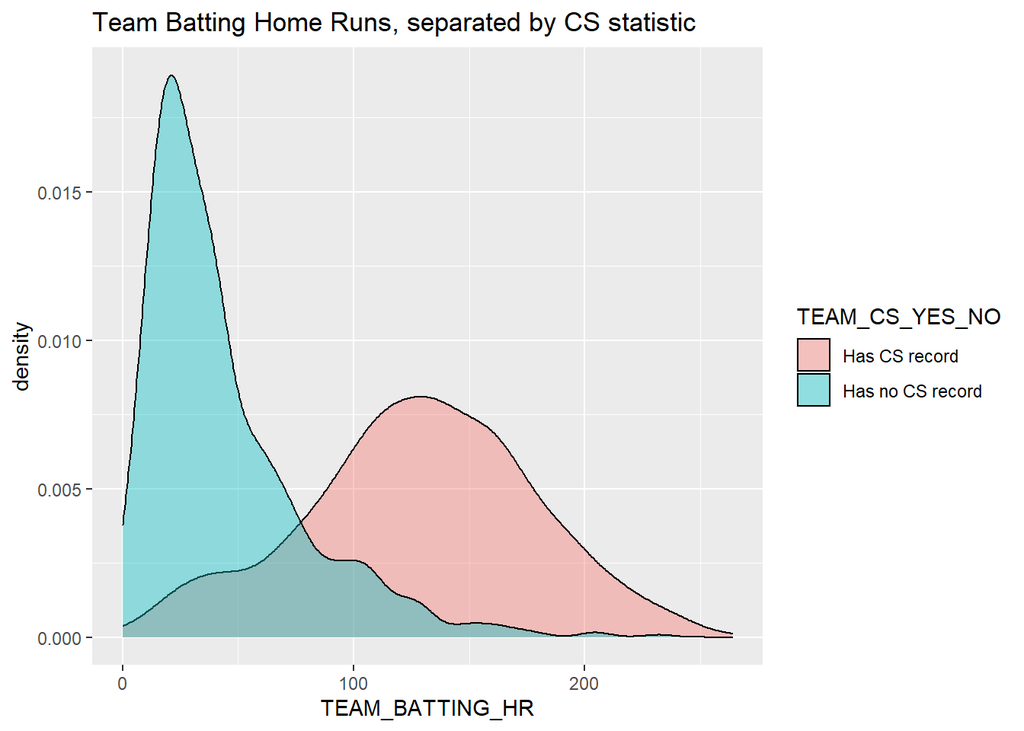

```r
ggplot(baseball_cs_dummy, aes(TEAM_BATTING_HR, fill = TEAM_CS_YES_NO)) +
  ggtitle('Team Batting Home Runs, separated by CS statistic') +
  geom_density(alpha = 0.4)
```

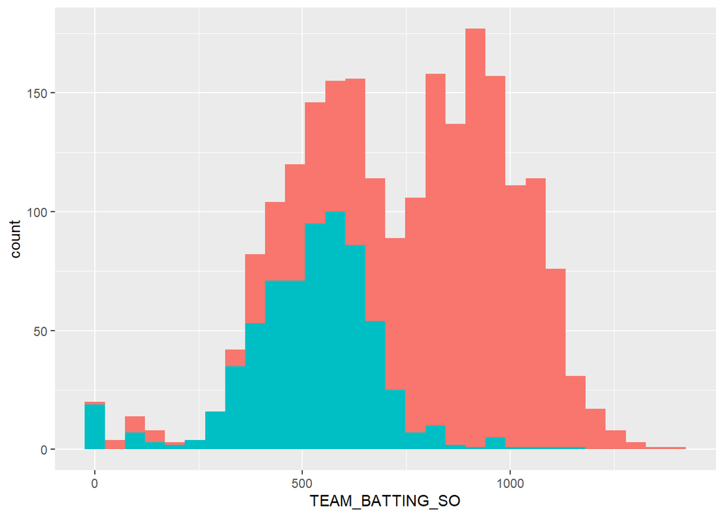

```r
ggplot(baseball_cs_dummy, aes(x = TEAM_BATTING_SO, fill = TEAM_CS_YES_NO)) +
  geom_histogram() +
  theme(legend.position = 'none')
```

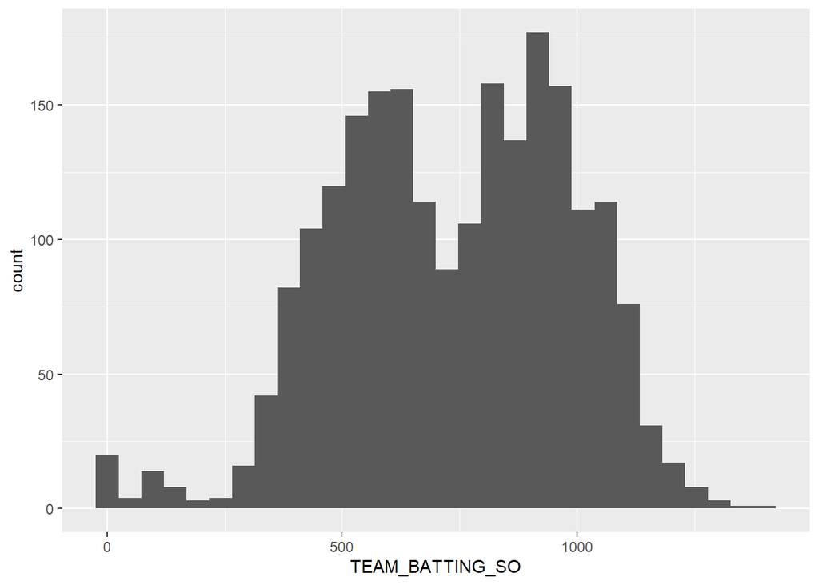

```r
ggplot(baseball_df, aes(x = TEAM_BATTING_SO)) +
  geom_histogram()
```

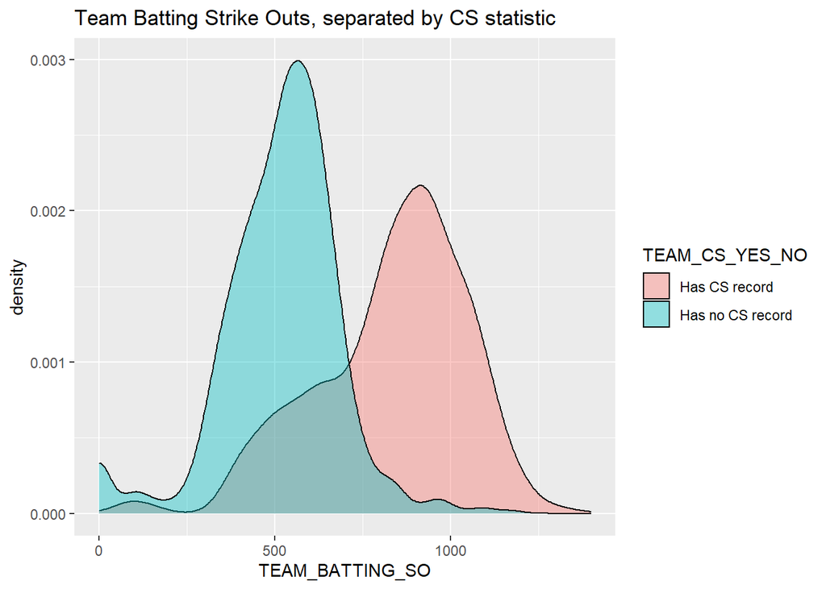

```r
ggplot(baseball_cs_dummy, aes(TEAM_BATTING_SO, fill = TEAM_CS_YES_NO)) +
  ggtitle('Team Batting Strike Outs, separated by CS statistic') +
  geom_density(alpha = 0.4)
```

```r
print('TEAM_BATTING_HR')
```

```
## [1] "TEAM_BATTING_HR"
```

```r
t.test(baseball_cs_dummy$TEAM_BATTING_HR[baseball_cs_dummy$TEAM_CS_YES_NO == 'Has CS record'], baseball_cs_dummy$TEAM_BATTING_HR[baseball_cs_dummy$TEAM_CS_YES_NO == 'Has no CS record'])
```

```
##
##  Welch Two Sample t-test
##
## data:  baseball_cs_dummy$TEAM_BATTING_HR[baseball_cs_dummy$TEAM_CS_YES_NO ==  and baseball_cs_dummy$TEAM_BATTING_HR[baseball_cs_dummy$TEAM_CS_YES_NO ==     "Has CS record"] and     "Has no CS record"]
## t = 47.771, df = 2094.9, p-value < 2.2e-16
## alternative hypothesis: true difference in means is not equal to 0
## 95 percent confidence interval:
##  81.58243 88.56750
## sample estimates:
## mean of x mean of y
## 128.46875  43.39378
```

```r
print('TEAM_PITCHING_HR')
```

```
## [1] "TEAM_PITCHING_HR"
```

```r
t.test(baseball_cs_dummy$TEAM_PITCHING_HR[baseball_cs_dummy$TEAM_CS_YES_NO == 'Has CS record'], baseball_cs_dummy$TEAM_PITCHING_HR[baseball_cs_dummy$TEAM_CS_YES_NO == 'Has no CS record'])
```

```
##
##  Welch Two Sample t-test
##
## data:  baseball_cs_dummy$TEAM_PITCHING_HR[baseball_cs_dummy$TEAM_CS_YES_NO ==  and baseball_cs_dummy$TEAM_PITCHING_HR[baseball_cs_dummy$TEAM_CS_YES_NO ==     "Has CS record"] and     "Has no CS record"]
## t = 41.486, df = 1949.1, p-value < 2.2e-16
## alternative hypothesis: true difference in means is not equal to 0
## 95 percent confidence interval:
##  77.00582 84.64777
## sample estimates:
## mean of x mean of y
## 133.11436  52.28756
```

```r
print('TEAM_BATTING_SO')
```

```
## [1] "TEAM_BATTING_SO"
```

```r
t.test(baseball_cs_dummy$TEAM_BATTING_SO[baseball_cs_dummy$TEAM_CS_YES_NO == 'Has CS record'], baseball_cs_dummy$TEAM_BATTING_SO[baseball_cs_dummy$TEAM_CS_YES_NO == 'Has no CS record'])
```

```
##
##  Welch Two Sample t-test
##
## data:  baseball_cs_dummy$TEAM_BATTING_SO[baseball_cs_dummy$TEAM_CS_YES_NO ==  and baseball_cs_dummy$TEAM_BATTING_SO[baseball_cs_dummy$TEAM_CS_YES_NO ==     "Has CS record"] and     "Has no CS record"]
## t = 37.121, df = 1625, p-value < 2.2e-16
## alternative hypothesis: true difference in means is not equal to 0
## 95 percent confidence interval:
##  299.0254 332.3881
## sample estimates:
## mean of x mean of y
##  832.9023  517.1955
```

All three statistics conclude it’s unlikely these partitions of the data have the same mean. The t.test function also gives us the mean of each group as well.

```r
sd_so_record <- sd(baseball_cs_dummy$TEAM_BATTING_SO[baseball_cs_dummy$TEAM_CS_YES_NO == 'Has CS record'])
sd_so_no_record <- sd(baseball_cs_dummy$TEAM_BATTING_SO[baseball_cs_dummy$TEAM_CS_YES_NO == 'Has no CS record'], na.rm = TRUE)

sd_so_record
```

```
## [1] 214.8008
```

```r
sd_so_no_record
```

```
## [1] 167.0542
```

```r
batting_so_mix <- normalmixEM(baseball_df$TEAM_BATTING_SO[!is.na(baseball_df$TEAM_BATTING_SO)], lambda = 0.5, mu = c(517.1955, 832.9023), sigma = c(sd_so_record, sd_so_no_record))
```

```
## number of iterations= 277
```

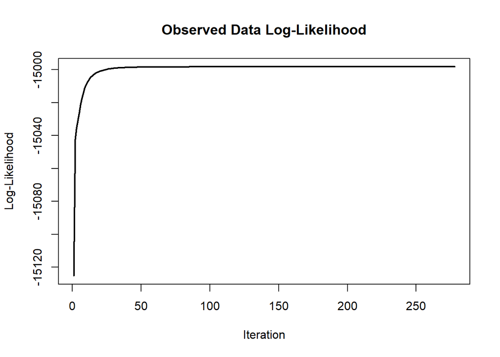

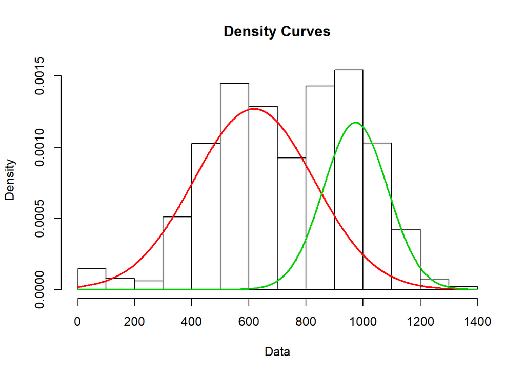

```r
plot(batting_so_mix, density = TRUE)
```

From here, there are options to model the difference. A new feature called TEAM_BATTING_SO_BIMODAL could be created, which provides a probability that a given entry falls into category A or B. For example, for low values this value could be close to zero and increase to near certainty once past the second mode. Values in the middle would have probabilities closer to 0.5. Another more labor intensive option would be to dissect the dataset temporarily and identify differences in summary statistics and correlations for the remaining variables. Finally, if there little to no overlap between the two distributions, they could be modeled using a binary dummy variable based off an intermodal threshold. This strategy would also benefit from finding correlations to the new dummy variable that would identify which observable values are causing the bimodal distribution, if any.

Sources:

https://cran.r-project.org/web/packages/mixtools/vignettes/mixtools.pdf